**S. Punati K-State Honor Code"On my honor, as a student, I have neither given nor received unauthorized aid on this academic work."**

Google Drive URL: https://www.youtube.com/watch?v=RcbEbsC_LJs

# 1. Business and data understanding

- What makes a movie successful? The right combination of talent, chemistry, and timing, all with some good luck?
- How can we tell the greatness of a movie before it is released in cinema?

These questions puzzled me for a long time since there is no universal way to claim the goodness of movies. Many people rely on critics to gauge the quality of a film, while others use their instincts. But it takes the time to obtain a reasonable amount of critics review after a movie is released. And human instinct sometimes is unreliable. Given that thousands of movies were produced each year, is there a better way for us to tell the greatness of movie without relying on critics or our own instincts?

**Objective:** Though there are many factors that comprise a movie’s success, and it is not always clear how they interact, this project attempts to determine these factors through the use of machine learning techniques.

**If you’re hired as a data/business analyst to predict how well a movie will perform in theaters, what kind of data would you collect?**

The first step to start the analysis is to collect data. We could collect data from multiple sources like IMDB, Netflix, Rotten Tomatoes, and Wikipedia and merge it. This mechanism works when these sites makes their data available through APIs (or) through webscrapping.

- From IMDB (provided datadaset), we could obtain for each movie: movie title, IMDB rating, plot description, budget, box office gross, and opening weekend gross.
- From Netflix, we could obtain frequency of each movie played, popularity, highest ratings.
- From Rotten Tomatoes, we could obtain critic score, audience score, runtime, MPAA rating, studio, theater release date, DVD release date, list of genres, abridged list of cast, and abridged list of directors.
- From Wikipedia, we could obtain the number of Academy Awards that actors and directors in each movie had won prior to that movie, and also the number of Best Picture films that actors and directors in each movie had been involved in, also prior to that movie.

To keep it simple for this project, I am going to use the provided dataset 'movie_metadata.csv' which cintains below features.

**movie_title:** Title of the Movie  
**duration:** Duration in minutes  
**director_name:** Name of the Director of the Movie  
**director_facebook_likes:** Number of likes of the Director on his Facebook Page  
**actor_1_name:** Primary actor starring in the movie  
**actor_1_facebook_likes:** Number of likes of the Actor_1 on his/her Facebook Page  
**actor_2_name:** Other actor starring in the movie  
**actor_2_facebook_likes:** Number of likes of the Actor_2 on his/her Facebook Page  
**actor_3_name:** Other actor starring in the movie  
**actor_3_facebook_likes:** Number of likes of the Actor_3 on his/her Facebook Page  
**num_user_for_reviews:** Number of users who gave a review  
**num_critic_for_reviews:** Number of critical reviews on imdb  
**num_voted_users:** Number of people who voted for the movie  
**cast_total_facebook_likes:** Total number of facebook likes of the entire cast of the movie  
**movie_facebook_likes:** Number of Facebook likes in the movie page  
**plot_keywords:** Keywords describing the movie plot  
**facenumber_in_poster:** Number of the actor who featured in the movie poster  
**color:** Film colorization. ‘Black and White’ or ‘Color’  
**genres:** Film categorization like ‘Animation’, ‘Comedy’, ‘Romance’, ‘Horror’, ‘Sci-Fi’, ‘Action’, ‘Family’  
**title_year:** The year in which the movie is released (1916:2016)  
**language:** English, Arabic, Chinese, French, German, Danish, Italian, Japanese etc  
**country:** Country where the movie is produced  
**content_rating :** Content rating of the movie  
**aspect_ratio :** Aspect ratio the movie was made in  
**movie_imdb_link :** IMDB link of the movie  
**gross :** Gross earnings of the movie in Dollars  
**budget :** Budget of the movie in Dollars  
**imdb_score :** IMDB Score of the movie on IMDB

**What variables are highly correlated to imdb score? In this project, you will use imdb_score to measure a movie’s success.**

imdb_score is just significantly positively correlated with...

1. num_critic_for_reviews, assuming a succesfull movie would draw as many critics as favourites.
2. duration, assuming duration of a movie contribures to scuccess.
3. num_voted_users, assuming high favourable votes contributes to success.
4. num_user_for_reviews, assuming high number of reviews possibly good certainly contributes to success.

There are no significant negative correlation with imdb_Score in this project dataset.

```python
# import packages
import pandas as pd
import numpy as np
import seaborn as sns
import matplotlib.pyplot as plt
%matplotlib inline

#regression packages (machine learning)
import sklearn.linear_model as lm
#for model evaluation
from sklearn.metrics import mean_squared_error
from sklearn.metrics import explained_variance_score

#lasso regression
from sklearn import linear_model

#f_regression (feature selection)
from sklearn.feature_selection import f_regression
from sklearn.feature_selection import SelectKBest

# recursive feature selection (feature selection)
from sklearn.feature_selection import RFE

#regression (statistics)
import statsmodels.api as sm
from statsmodels.formula.api import ols

#import decisiontreeclassifier
from sklearn import tree
from sklearn.tree import DecisionTreeClassifier, export_graphviz
from IPython.display import SVG

#from graphviz import Source
from IPython.display import display

#import logisticregression classifier
from sklearn.linear_model import LogisticRegression
import statsmodels.api as sm

#import knn classifier
from sklearn.neighbors import KNeighborsClassifier

#for validating your classification model
from sklearn.metrics import classification_report, f1_score, accuracy_score, confusion_matrix
from sklearn.model_selection import StratifiedKFold, cross_val_score, train_test_split, GridSearchCV
from sklearn import metrics
from sklearn.metrics import roc_curve, auc, roc_auc_score

# feature selection
from sklearn.feature_selection import RFE
from sklearn.ensemble import ExtraTreesClassifier
from sklearn.feature_selection import SelectKBest
from sklearn.feature_selection import chi2

# advanced algorthms
from sklearn.neural_network import MLPClassifier
from sklearn.ensemble import GradientBoostingClassifier
from sklearn.svm import SVC

#pip install scikit-plot (optional)
import scikitplot as skplt

import warnings
warnings.filterwarnings("ignore")

from sklearn.cluster import KMeans
from sklearn import cluster
import matplotlib.pyplot as plt
import mpl_toolkits.mplot3d.axes3d as p3
from mpl_toolkits.mplot3d import Axes3D

from sklearn.metrics.pairwise import pairwise_distances_argmin
from scipy.spatial.distance import cdist
from sklearn import metrics
from sklearn.metrics import silhouette_samples, silhouette_score
import matplotlib.cm as cm

from sklearn.cluster import AgglomerativeClustering
from sklearn.cluster import ward_tree
from scipy.cluster.hierarchy import dendrogram, linkage, ward

from sklearn import tree
```

# 2. Data ETL

We have 5043 observations of 28 variables. The response/dependent variable “imdb_score” is numerical, and the independent features/variables are mixed with both numerical and categorical variables.

```python
# read data
mvdata=pd.read_csv("movie_metadata.csv")
mvdata.head()
```

|  | color | director_name | num_critic_for_reviews | duration | director_facebook_likes | actor_3_facebook_likes | actor_2_name | actor_1_facebook_likes | gross | genres | ... | num_user_for_reviews | language | country | content_rating | budget | title_year | actor_2_facebook_likes | imdb_score | aspect_ratio | movie_facebook_likes |
| --- | --- | --- | --- | --- | --- | --- | --- | --- | --- | --- | --- | --- | --- | --- | --- | --- | --- | --- | --- | --- | --- |
| 0 | Color | James Cameron | 723.0 | 178.0 | 0.0 | 855.0 | Joel David Moore | 1000.0 | 760505847.0 | Action\|Adventure\|Fantasy\|Sci-Fi | ... | 3054.0 | English | USA | PG-13 | 237000000.0 | 2009.0 | 936.0 | 7.9 | 1.78 | 33000 |
| 1 | Color | Gore Verbinski | 302.0 | 169.0 | 563.0 | 1000.0 | Orlando Bloom | 40000.0 | 309404152.0 | Action\|Adventure\|Fantasy | ... | 1238.0 | English | USA | PG-13 | 300000000.0 | 2007.0 | 5000.0 | 7.1 | 2.35 | 0 |
| 2 | Color | Sam Mendes | 602.0 | 148.0 | 0.0 | 161.0 | Rory Kinnear | 11000.0 | 200074175.0 | Action\|Adventure\|Thriller | ... | 994.0 | English | UK | PG-13 | 245000000.0 | 2015.0 | 393.0 | 6.8 | 2.35 | 85000 |
| 3 | Color | Christopher Nolan | 813.0 | 164.0 | 22000.0 | 23000.0 | Christian Bale | 27000.0 | 448130642.0 | Action\|Thriller | ... | 2701.0 | English | USA | PG-13 | 250000000.0 | 2012.0 | 23000.0 | 8.5 | 2.35 | 164000 |
| 4 | NaN | Doug Walker | NaN | NaN | 131.0 | NaN | Rob Walker | 131.0 | NaN | Documentary | ... | NaN | NaN | NaN | NaN | NaN | NaN | 12.0 | 7.1 | NaN | 0 |

5 rows × 28 columns

```python
# find out data types ...
rows, column = mvdata.shape
print("Rows:{} columns:{}".format(rows, column))

mvdata.info()
```

```
Rows:5043 columns:28
<class 'pandas.core.frame.DataFrame'>
RangeIndex: 5043 entries, 0 to 5042
Data columns (total 28 columns):
color                        5024 non-null object
director_name                4939 non-null object
num_critic_for_reviews       4993 non-null float64
duration                     5028 non-null float64
director_facebook_likes      4939 non-null float64
actor_3_facebook_likes       5020 non-null float64
actor_2_name                 5030 non-null object
actor_1_facebook_likes       5036 non-null float64
gross                        4159 non-null float64
genres                       5043 non-null object
actor_1_name                 5036 non-null object
movie_title                  5043 non-null object
num_voted_users              5043 non-null int64
cast_total_facebook_likes    5043 non-null int64
actor_3_name                 5020 non-null object
facenumber_in_poster         5030 non-null float64
plot_keywords                4890 non-null object
movie_imdb_link              5043 non-null object
num_user_for_reviews         5022 non-null float64
language                     5031 non-null object
country                      5038 non-null object
content_rating               4740 non-null object
budget                       4551 non-null float64
title_year                   4935 non-null float64
actor_2_facebook_likes       5030 non-null float64
imdb_score                   5043 non-null float64
aspect_ratio                 4714 non-null float64
movie_facebook_likes         5043 non-null int64
dtypes: float64(13), int64(3), object(12)
memory usage: 1.1+ MB
```

- **All fields should be numerical for correlation analaysis.**
- **Any categorical columns need to be converted to number columns using ETL.**
- **Let's go by each column to understand the significance, drop it if it's not significant.**

```python
#copy dataframe for vizulization purpose
mvdata_v = mvdata.copy()
```

## 2.1 Exploratory data analysis:

**color:**

```
['Color' nan ' Black and White']
```

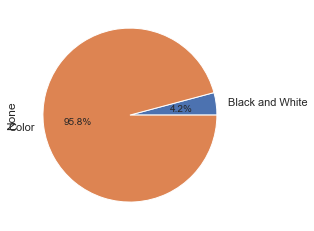

```python
# find out unique values in color ...
print(mvdata['color'].unique())
mvdata.groupby('color').size().plot(kind='pie',autopct='%.1f%%');
```

- **Nearly than 96% movies are colored, which indicates that this feature is nearly constant.**
- **So let’s drop this variable in later section.**

**language:**

```
['English' nan 'Japanese' 'French' 'Mandarin' 'Aboriginal' 'Spanish'
 'Filipino' 'Hindi' 'Russian' 'Maya' 'Kazakh' 'Telugu' 'Cantonese'
 'Icelandic' 'German' 'Aramaic' 'Italian' 'Dutch' 'Dari' 'Hebrew'
 'Chinese' 'Mongolian' 'Swedish' 'Korean' 'Thai' 'Polish' 'Bosnian' 'None'
 'Hungarian' 'Portuguese' 'Danish' 'Arabic' 'Norwegian' 'Czech' 'Kannada'
 'Zulu' 'Panjabi' 'Tamil' 'Dzongkha' 'Vietnamese' 'Indonesian' 'Urdu'
 'Romanian' 'Persian' 'Slovenian' 'Greek' 'Swahili']
```

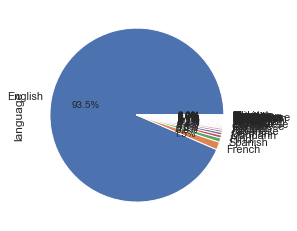

```python
# find out unique language...
print(mvdata['language'].unique())
#mvdata.groupby('language').size().plot(kind='pie',autopct='%.1f%%');
mvdata['language'].value_counts().plot(kind='pie',autopct='%.1f%%');
```

- **Nearly than 94% movies are English, which indicates that this feature is nearly constant.**
- **So Let’s drop this variable in later section.**

**country:**

```
['USA' 'UK' nan 'New Zealand' 'Canada' 'Australia' 'Belgium' 'Japan'
 'Germany' 'China' 'France' 'New Line' 'Mexico' 'Spain' 'Hong Kong'
 'Czech Republic' 'India' 'Soviet Union' 'South Korea' 'Peru' 'Italy'
 'Russia' 'Aruba' 'Denmark' 'Libya' 'Ireland' 'South Africa' 'Iceland'
 'Switzerland' 'Romania' 'West Germany' 'Chile' 'Netherlands' 'Hungary'
 'Panama' 'Greece' 'Sweden' 'Norway' 'Taiwan' 'Official site' 'Cambodia'
 'Thailand' 'Slovakia' 'Bulgaria' 'Iran' 'Poland' 'Georgia' 'Turkey'
 'Nigeria' 'Brazil' 'Finland' 'Bahamas' 'Argentina' 'Colombia' 'Israel'
 'Egypt' 'Kyrgyzstan' 'Indonesia' 'Pakistan' 'Slovenia' 'Afghanistan'
 'Dominican Republic' 'Cameroon' 'United Arab Emirates' 'Kenya'
 'Philippines']
```

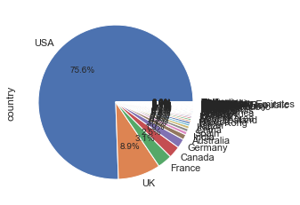

```python
# find out unique country ...
print(mvdata['country'].unique())
#mvdata.groupby('country').size().head().plot(kind='pie',autopct='%.1f%%');
mvdata['country'].value_counts().plot(kind='pie',autopct='%.1f%%');
```

- **Nearly 76% movies are USA, 9% UK, 15% other country movies. So let's group other countries together to make this categorical variable with less levels: USA, UK, Others.**

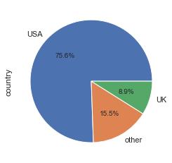

```python
# create categories for country ...
mvdata.country.replace(['nan', 'New Zealand', 'Canada', 'Australia', 'Belgium',
       'Japan', 'Germany', 'China', 'France', 'New Line', 'Mexico',
       'Spain', 'Hong Kong', 'Czech Republic', 'India', 'Soviet Union',
       'South Korea', 'Peru', 'Italy', 'Russia', 'Aruba', 'Denmark',
       'Libya', 'Ireland', 'South Africa', 'Iceland', 'Switzerland',
       'Romania', 'West Germany', 'Chile', 'Netherlands', 'Hungary',
       'Panama', 'Greece', 'Sweden', 'Norway', 'Taiwan', 'Official site',
       'Cambodia', 'Thailand', 'Slovakia', 'Bulgaria', 'Iran', 'Poland',
       'Georgia', 'Turkey', 'Nigeria', 'Brazil', 'Finland', 'Bahamas',
       'Argentina', 'Colombia', 'Israel', 'Egypt', 'Kyrgyzstan',
       'Indonesia', 'Pakistan', 'Slovenia', 'Afghanistan',
       'Dominican Republic', 'Cameroon', 'United Arab Emirates', 'Kenya',
       'Philippines'], 'other', inplace=True)
mvdata['country'].value_counts().plot(kind='pie',autopct='%.1f%%');
```

```python
# Create dummy variables for country
mvdata = pd.get_dummies(mvdata, columns=['country'])
mvdata.head(3)
```

|  | color | director_name | num_critic_for_reviews | duration | director_facebook_likes | actor_3_facebook_likes | actor_2_name | actor_1_facebook_likes | gross | genres | ... | content_rating | budget | title_year | actor_2_facebook_likes | imdb_score | aspect_ratio | movie_facebook_likes | country_UK | country_USA | country_other |
| --- | --- | --- | --- | --- | --- | --- | --- | --- | --- | --- | --- | --- | --- | --- | --- | --- | --- | --- | --- | --- | --- |
| 0 | Color | James Cameron | 723.0 | 178.0 | 0.0 | 855.0 | Joel David Moore | 1000.0 | 760505847.0 | Action\|Adventure\|Fantasy\|Sci-Fi | ... | PG-13 | 237000000.0 | 2009.0 | 936.0 | 7.9 | 1.78 | 33000 | 0 | 1 | 0 |
| 1 | Color | Gore Verbinski | 302.0 | 169.0 | 563.0 | 1000.0 | Orlando Bloom | 40000.0 | 309404152.0 | Action\|Adventure\|Fantasy | ... | PG-13 | 300000000.0 | 2007.0 | 5000.0 | 7.1 | 2.35 | 0 | 0 | 1 | 0 |
| 2 | Color | Sam Mendes | 602.0 | 148.0 | 0.0 | 161.0 | Rory Kinnear | 11000.0 | 200074175.0 | Action\|Adventure\|Thriller | ... | PG-13 | 245000000.0 | 2015.0 | 393.0 | 6.8 | 2.35 | 85000 | 1 | 0 | 0 |

3 rows × 30 columns

- **genres:**

```python
# find out unique values in genres ...
mvdata['genres'].unique()[:5]
```

```
array(['Action|Adventure|Fantasy|Sci-Fi', 'Action|Adventure|Fantasy',
       'Action|Adventure|Thriller', 'Action|Thriller', 'Documentary'],
      dtype=object)
```

```python
# separate a string of genres into multiple dummy variables
mvdata_g = mvdata[['imdb_score']].join(mvdata['genres'].str.get_dummies('|'))
mvdata_g.head(2)
```

|  | imdb_score | Action | Adventure | Animation | Biography | Comedy | Crime | Documentary | Drama | Family | ... | Mystery | News | Reality-TV | Romance | Sci-Fi | Short | Sport | Thriller | War | Western |
| --- | --- | --- | --- | --- | --- | --- | --- | --- | --- | --- | --- | --- | --- | --- | --- | --- | --- | --- | --- | --- | --- |
| 0 | 7.9 | 1 | 1 | 0 | 0 | 0 | 0 | 0 | 0 | 0 | ... | 0 | 0 | 0 | 0 | 1 | 0 | 0 | 0 | 0 | 0 |
| 1 | 7.1 | 1 | 1 | 0 | 0 | 0 | 0 | 0 | 0 | 0 | ... | 0 | 0 | 0 | 0 | 0 | 0 | 0 | 0 | 0 | 0 |

2 rows × 27 columns

```python
#convert all genres to numbers from object type
mvdata_g = mvdata_g.apply(pd.to_numeric)
```

```python
mvdata_g.columns
```

```
Index(['imdb_score', 'Action', 'Adventure', 'Animation', 'Biography', 'Comedy',
       'Crime', 'Documentary', 'Drama', 'Family', 'Fantasy', 'Film-Noir',
       'Game-Show', 'History', 'Horror', 'Music', 'Musical', 'Mystery', 'News',
       'Reality-TV', 'Romance', 'Sci-Fi', 'Short', 'Sport', 'Thriller', 'War',
       'Western'],
      dtype='object')
```

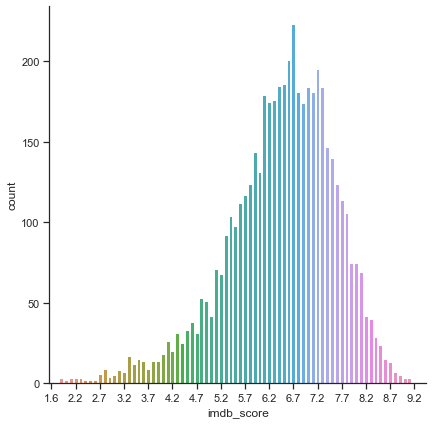

```python
#Distribution of the IMDB ratings
g = sns.catplot('imdb_score', data=mvdata_g, kind='count', height= 6)
g.set_xticklabels(step=5)
```

- **imdb_score with repect to geners is normally distributed , that mean imdb_score in this case is a parametric value.**
- **Let's look at individual distribution of genre across imdb_score**

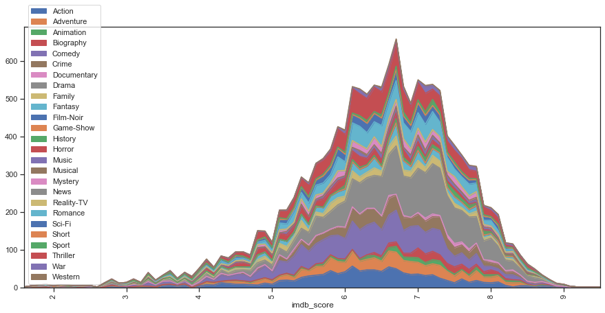

```python
# Individual distribution of genre across imdb_score
mvdata_g.groupby('imdb_score').sum().plot(kind='area',figsize=(15,7), rot=90)
```

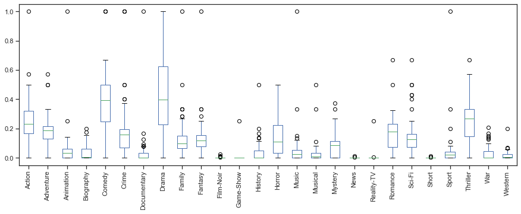

```python
# look at individual distribution of genre across imdb_score
mvdata_g.groupby('imdb_score').mean().plot(kind='box',figsize=(15,5), rot=90)
```

```python
# find out some descriptive statistics
mvdata.describe()
```

|  | num_critic_for_reviews | duration | director_facebook_likes | actor_3_facebook_likes | actor_1_facebook_likes | gross | num_voted_users | cast_total_facebook_likes | facenumber_in_poster | num_user_for_reviews | budget | title_year | actor_2_facebook_likes | imdb_score | aspect_ratio | movie_facebook_likes | country_UK | country_USA | country_other |
| --- | --- | --- | --- | --- | --- | --- | --- | --- | --- | --- | --- | --- | --- | --- | --- | --- | --- | --- | --- |
| count | 4993.000000 | 5028.000000 | 4939.000000 | 5020.000000 | 5036.000000 | 4.159000e+03 | 5.043000e+03 | 5043.000000 | 5030.000000 | 5022.000000 | 4.551000e+03 | 4935.000000 | 5030.000000 | 5043.000000 | 4714.000000 | 5043.000000 | 5043.000000 | 5043.000000 | 5043.000000 |
| mean | 140.194272 | 107.201074 | 686.509212 | 645.009761 | 6560.047061 | 4.846841e+07 | 8.366816e+04 | 9699.063851 | 1.371173 | 272.770808 | 3.975262e+07 | 2002.470517 | 1651.754473 | 6.442138 | 2.220403 | 7525.964505 | 0.088836 | 0.754908 | 0.155265 |
| std | 121.601675 | 25.197441 | 2813.328607 | 1665.041728 | 15020.759120 | 6.845299e+07 | 1.384853e+05 | 18163.799124 | 2.013576 | 377.982886 | 2.061149e+08 | 12.474599 | 4042.438863 | 1.125116 | 1.385113 | 19320.445110 | 0.284535 | 0.430185 | 0.362193 |
| min | 1.000000 | 7.000000 | 0.000000 | 0.000000 | 0.000000 | 1.620000e+02 | 5.000000e+00 | 0.000000 | 0.000000 | 1.000000 | 2.180000e+02 | 1916.000000 | 0.000000 | 1.600000 | 1.180000 | 0.000000 | 0.000000 | 0.000000 | 0.000000 |
| 25% | 50.000000 | 93.000000 | 7.000000 | 133.000000 | 614.000000 | 5.340988e+06 | 8.593500e+03 | 1411.000000 | 0.000000 | 65.000000 | 6.000000e+06 | 1999.000000 | 281.000000 | 5.800000 | 1.850000 | 0.000000 | 0.000000 | 1.000000 | 0.000000 |
| 50% | 110.000000 | 103.000000 | 49.000000 | 371.500000 | 988.000000 | 2.551750e+07 | 3.435900e+04 | 3090.000000 | 1.000000 | 156.000000 | 2.000000e+07 | 2005.000000 | 595.000000 | 6.600000 | 2.350000 | 166.000000 | 0.000000 | 1.000000 | 0.000000 |
| 75% | 195.000000 | 118.000000 | 194.500000 | 636.000000 | 11000.000000 | 6.230944e+07 | 9.630900e+04 | 13756.500000 | 2.000000 | 326.000000 | 4.500000e+07 | 2011.000000 | 918.000000 | 7.200000 | 2.350000 | 3000.000000 | 0.000000 | 1.000000 | 0.000000 |
| max | 813.000000 | 511.000000 | 23000.000000 | 23000.000000 | 640000.000000 | 7.605058e+08 | 1.689764e+06 | 656730.000000 | 43.000000 | 5060.000000 | 1.221550e+10 | 2016.000000 | 137000.000000 | 9.500000 | 16.000000 | 349000.000000 | 1.000000 | 1.000000 | 1.000000 |

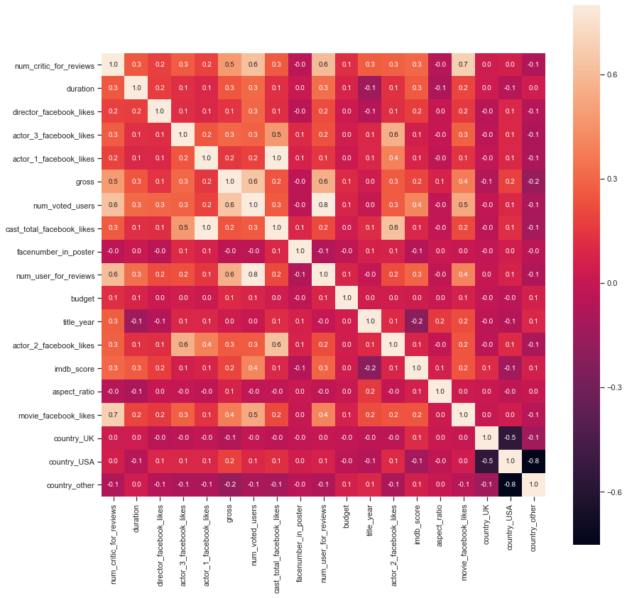

```python
# correlation plot
plt.figure(figsize=(14,14))
sns.heatmap(mvdata.corr(), vmax=.8, square=True, annot=True, fmt=".1f");
```

Assuming only -/+ 0.3 correlation coefficient is good enough to define a significant relation between two variables..we can draw below conclusions...

**imdb_score is just significantly Positively correlated with...**

1. num_critic_for_reviews (0.3)
2. duration (0.3)
3. num_voted_users (0.4)
4. num_user_for_reviews (0.3)

**There are no significant negative correlation with imdb_score.**

**Other important correlations within features are..**

**We find cast_total_facebook_likes is highly correlated with the actor_1_facebook_likes,actor_2_facebook_likes and actor_3_facebook_likes. That might be because cast_total_facebook_likes is sum of the latter variables. So let's just remove it and make 2 categories : actor_1_facebook_likes and other_actors_facebook_likes.**

```python
mvdata['other_actors_facebook_likes'] = mvdata['actor_2_facebook_likes']+mvdata['actor_3_facebook_likes']
mvdata.head(1)
```

|  | color | director_name | num_critic_for_reviews | duration | director_facebook_likes | actor_3_facebook_likes | actor_2_name | actor_1_facebook_likes | gross | genres | ... | budget | title_year | actor_2_facebook_likes | imdb_score | aspect_ratio | movie_facebook_likes | country_UK | country_USA | country_other | other_actors_facebook_likes |
| --- | --- | --- | --- | --- | --- | --- | --- | --- | --- | --- | --- | --- | --- | --- | --- | --- | --- | --- | --- | --- | --- |
| 0 | Color | James Cameron | 723.0 | 178.0 | 0.0 | 855.0 | Joel David Moore | 1000.0 | 760505847.0 | Action\|Adventure\|Fantasy\|Sci-Fi | ... | 237000000.0 | 2009.0 | 936.0 | 7.9 | 1.78 | 33000 | 0 | 1 | 0 | 1791.0 |

1 rows × 31 columns

```python
# find out the correlation of two columns: imdb_score, num_voted_users
mvdata[['imdb_score','num_voted_users']].corr()
```

|  | imdb_score | num_voted_users |
| --- | --- | --- |
| imdb_score | 1.000000 | 0.410965 |
| num_voted_users | 0.410965 | 1.000000 |

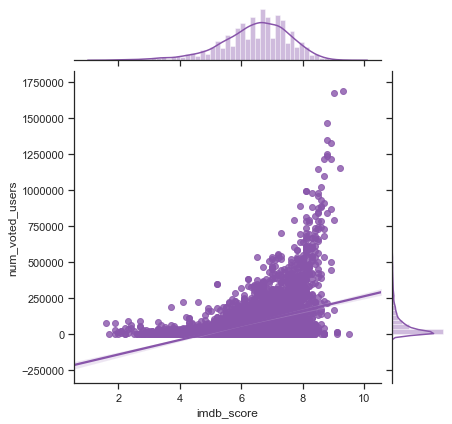

```python
# jointplott for imdb_score and num_voted_users
sns.jointplot("imdb_score", "num_voted_users", mvdata, kind="reg", color="#8855AA")
```

- **num_voted_users does seem to have positive impact on imdb_score/success of a movie, so let's use this for further analysis.**

## 2.2 Data Cleansing

### 2.2.1 Drop duplicates

```python
# check duplicate rows based on the movie_title column
mask = mvdata.movie_title.duplicated(keep=False)
mask.head(2)
```

```
0    False
1    False
Name: movie_title, dtype: bool
```

```python
# display those rows for review
mvdata[mask].sort_values('movie_title').head()
```

|  | color | director_name | num_critic_for_reviews | duration | director_facebook_likes | actor_3_facebook_likes | actor_2_name | actor_1_facebook_likes | gross | genres | ... | budget | title_year | actor_2_facebook_likes | imdb_score | aspect_ratio | movie_facebook_likes | country_UK | country_USA | country_other | other_actors_facebook_likes |
| --- | --- | --- | --- | --- | --- | --- | --- | --- | --- | --- | --- | --- | --- | --- | --- | --- | --- | --- | --- | --- | --- |
| 3711 | Color | Richard Fleischer | 69.0 | 127.0 | 130.0 | 51.0 | Robert J. Wilke | 617.0 | NaN | Adventure\|Drama\|Family\|Fantasy\|Sci-Fi | ... | 5000000.0 | 1954.0 | 53.0 | 7.2 | 1.37 | 0 | 0 | 1 | 0 | 104.0 |
| 4894 | Color | Richard Fleischer | 69.0 | 127.0 | 130.0 | 51.0 | Robert J. Wilke | 618.0 | NaN | Adventure\|Drama\|Family\|Fantasy\|Sci-Fi | ... | 5000000.0 | 1954.0 | 53.0 | 7.2 | 1.37 | 0 | 0 | 1 | 0 | 104.0 |
| 4950 | Color | David Hewlett | 8.0 | 88.0 | 686.0 | 405.0 | David Hewlett | 847.0 | NaN | Comedy | ... | 120000.0 | 2007.0 | 686.0 | 7.0 | 1.78 | 377 | 0 | 0 | 1 | 1091.0 |
| 4949 | Color | David Hewlett | 8.0 | 88.0 | 686.0 | 405.0 | David Hewlett | 847.0 | NaN | Comedy | ... | 120000.0 | 2007.0 | 686.0 | 7.0 | 1.78 | 377 | 0 | 0 | 1 | 1091.0 |
| 1420 | Color | Wes Craven | 256.0 | 101.0 | 0.0 | 574.0 | Lin Shaye | 40000.0 | 26505000.0 | Horror | ... | 1800000.0 | 1984.0 | 852.0 | 7.5 | 1.85 | 10000 | 0 | 1 | 0 | 1426.0 |

5 rows × 31 columns

```python
# find out how many
len(mvdata[mask].sort_values('movie_title'))
```

```
245
```

```python
# now drop those duplicated
mvdata = mvdata.drop_duplicates(subset='movie_title', keep="first")
len(mvdata)
```

```
4917
```

### 2.2.1 Drop columns

```python
#drop 'genre' column, because we proved that it doesn't significantly correlate with idmb_score
mvdata = mvdata.drop('genres', axis=1)

#drop 'cast_total_facebook_likes' coulmn, because it causes multicollinearity.
mvdata = mvdata.drop(['cast_total_facebook_likes','actor_2_facebook_likes','actor_3_facebook_likes'], axis=1)

#drop 'director name' coulmn, because it doesn't significantly correlate with idmb_score
mvdata = mvdata.drop('director_name', axis=1)

#drop 'actor name' columns , because they are not significant for predicting imdb_score
mvdata = mvdata.drop(['actor_1_name', 'actor_2_name', 'actor_3_name'], axis=1)

#drop 'color' column, because this feature is nearly constant(color) and not significant for predicting imdb_score
mvdata = mvdata.drop('color', axis=1)

#drop 'language' column, because this feature is nearly constant(English) and not significant for predicting imdb_score
mvdata = mvdata.drop('language', axis=1)

#drop 'plot_keywords' column, because it is too diverse to be used in predicting imdb_score
mvdata = mvdata.drop('plot_keywords', axis=1)

#drop 'movie_imdb_link' column, because it is redundant feature to be used in predicting imdb_score
mvdata = mvdata.drop('movie_imdb_link', axis=1)
```

```python
mvdata.head(3)
```

|  | num_critic_for_reviews | duration | director_facebook_likes | actor_1_facebook_likes | gross | movie_title | num_voted_users | facenumber_in_poster | num_user_for_reviews | content_rating | budget | title_year | imdb_score | aspect_ratio | movie_facebook_likes | country_UK | country_USA | country_other | other_actors_facebook_likes |
| --- | --- | --- | --- | --- | --- | --- | --- | --- | --- | --- | --- | --- | --- | --- | --- | --- | --- | --- | --- |
| 0 | 723.0 | 178.0 | 0.0 | 1000.0 | 760505847.0 | Avatar | 886204 | 0.0 | 3054.0 | PG-13 | 237000000.0 | 2009.0 | 7.9 | 1.78 | 33000 | 0 | 1 | 0 | 1791.0 |
| 1 | 302.0 | 169.0 | 563.0 | 40000.0 | 309404152.0 | Pirates of the Caribbean: At World's End | 471220 | 0.0 | 1238.0 | PG-13 | 300000000.0 | 2007.0 | 7.1 | 2.35 | 0 | 0 | 1 | 0 | 6000.0 |
| 2 | 602.0 | 148.0 | 0.0 | 11000.0 | 200074175.0 | Spectre | 275868 | 1.0 | 994.0 | PG-13 | 245000000.0 | 2015.0 | 6.8 | 2.35 | 85000 | 1 | 0 | 0 | 554.0 |

## 2.4 Data Pre-processing

```python
mvdata.info()
```

```
<class 'pandas.core.frame.DataFrame'>
Int64Index: 4917 entries, 0 to 5042
Data columns (total 19 columns):
num_critic_for_reviews         4868 non-null float64
duration                       4902 non-null float64
director_facebook_likes        4815 non-null float64
actor_1_facebook_likes         4910 non-null float64
gross                          4054 non-null float64
movie_title                    4917 non-null object
num_voted_users                4917 non-null int64
facenumber_in_poster           4904 non-null float64
num_user_for_reviews           4896 non-null float64
content_rating                 4617 non-null object
budget                         4433 non-null float64
title_year                     4811 non-null float64
imdb_score                     4917 non-null float64
aspect_ratio                   4591 non-null float64
movie_facebook_likes           4917 non-null int64
country_UK                     4917 non-null uint8
country_USA                    4917 non-null uint8
country_other                  4917 non-null uint8
other_actors_facebook_likes    4894 non-null float64
dtypes: float64(12), int64(2), object(2), uint8(3)
memory usage: 667.4+ KB
```

### 2.4.1 Bin Response Variable

Our goal is to build a model, which can help us predict if a movie is good or bad. So we don’t really want an exact score to be predicted, we only want to know how good or how bad is the movie. Therefore, we bin the score into 2 buckets: 0 ~ 5 and 5 ~ 10, which represents 0 (Bad) , 1(Good) respectively.

```python
bins = [0, 5, 10]
labels=[0,1]
mvdata['imdb_binned'] = pd.cut(mvdata['imdb_score'], bins , labels=labels)
mvdata.head(2)
```

|  | num_critic_for_reviews | duration | director_facebook_likes | actor_1_facebook_likes | gross | movie_title | num_voted_users | facenumber_in_poster | num_user_for_reviews | content_rating | budget | title_year | imdb_score | aspect_ratio | movie_facebook_likes | country_UK | country_USA | country_other | other_actors_facebook_likes | imdb_binned |
| --- | --- | --- | --- | --- | --- | --- | --- | --- | --- | --- | --- | --- | --- | --- | --- | --- | --- | --- | --- | --- |
| 0 | 723.0 | 178.0 | 0.0 | 1000.0 | 760505847.0 | Avatar | 886204 | 0.0 | 3054.0 | PG-13 | 237000000.0 | 2009.0 | 7.9 | 1.78 | 33000 | 0 | 1 | 0 | 1791.0 | 1 |
| 1 | 302.0 | 169.0 | 563.0 | 40000.0 | 309404152.0 | Pirates of the Caribbean: At World's End | 471220 | 0.0 | 1238.0 | PG-13 | 300000000.0 | 2007.0 | 7.1 | 2.35 | 0 | 0 | 1 | 0 | 6000.0 | 1 |

### 2.4.2 Data Imputation of missing values

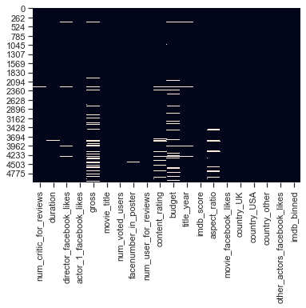

```python
#heatmap for null values
sns.heatmap(mvdata.isnull(), cbar=False)
```

```python
# Find sum of null values
mvdata.isnull().sum()
```

```
num_critic_for_reviews          49
duration                        15
director_facebook_likes        102
actor_1_facebook_likes           7
gross                          863
movie_title                      0
num_voted_users                  0
facenumber_in_poster            13
num_user_for_reviews            21
content_rating                 300
budget                         484
title_year                     106
imdb_score                       0
aspect_ratio                   326
movie_facebook_likes             0
country_UK                       0
country_USA                      0
country_other                    0
other_actors_facebook_likes     23
imdb_binned                      0
dtype: int64
```

- **Since gross and budget have too many missing values, and we want to keep these two variables for the following analysis.**
- **We can only delete rows with null values for gross and budget because imputation will not do a good job here.**

```python
#remove the rows with missing values ...this removed 27% of observations
mvdata.dropna(subset=['gross', 'budget'], inplace=True)
rows, column = mvdata.shape
print("Rows:{} columns:{}".format(rows, column))
```

```
Rows:3789 columns:20
```

```python
mvdata.isnull().sum()
```

```
num_critic_for_reviews          1
duration                        1
director_facebook_likes         0
actor_1_facebook_likes          3
gross                           0
movie_title                     0
num_voted_users                 0
facenumber_in_poster            6
num_user_for_reviews            0
content_rating                 51
budget                          0
title_year                      0
imdb_score                      0
aspect_ratio                   74
movie_facebook_likes            0
country_UK                      0
country_USA                     0
country_other                   0
other_actors_facebook_likes    10
imdb_binned                     0
dtype: int64
```

```python
mvdata.head(2)
```

|  | num_critic_for_reviews | duration | director_facebook_likes | actor_1_facebook_likes | gross | movie_title | num_voted_users | facenumber_in_poster | num_user_for_reviews | content_rating | budget | title_year | imdb_score | aspect_ratio | movie_facebook_likes | country_UK | country_USA | country_other | other_actors_facebook_likes | imdb_binned |
| --- | --- | --- | --- | --- | --- | --- | --- | --- | --- | --- | --- | --- | --- | --- | --- | --- | --- | --- | --- | --- |
| 0 | 723.0 | 178.0 | 0.0 | 1000.0 | 760505847.0 | Avatar | 886204 | 0.0 | 3054.0 | PG-13 | 237000000.0 | 2009.0 | 7.9 | 1.78 | 33000 | 0 | 1 | 0 | 1791.0 | 1 |
| 1 | 302.0 | 169.0 | 563.0 | 40000.0 | 309404152.0 | Pirates of the Caribbean: At World's End | 471220 | 0.0 | 1238.0 | PG-13 | 300000000.0 | 2007.0 | 7.1 | 2.35 | 0 | 0 | 1 | 0 | 6000.0 | 1 |

```python
#Impute missing values of other numerical columns with mean

#  replace NA with column average for num_critic_for_reviews
mvdata.num_critic_for_reviews.fillna(0, inplace=True)
mvdata.num_critic_for_reviews.replace(0,  mvdata['num_critic_for_reviews'].mean(), inplace=True)

#  replace NA with column average for duration
mvdata.duration.replace(0,  mvdata['duration'].mean(), inplace=True)

#  replace NA with column average for director_facebook_likes
mvdata.director_facebook_likes.replace(0,  mvdata['director_facebook_likes'].mean(), inplace=True)

#  replace NA with column average for actor_1_facebook_likes
mvdata.actor_1_facebook_likes.fillna(0, inplace=True)
mvdata.actor_1_facebook_likes.replace(0,  mvdata['actor_1_facebook_likes'].mean(), inplace=True)

#  replace NA with column average for num_voted_users
mvdata.num_voted_users.replace(0,  mvdata['num_voted_users'].mean(), inplace=True)

#  replace NA with column average for facenumber_in_poster
mvdata.facenumber_in_poster.fillna(0, inplace=True)
mvdata.facenumber_in_poster.replace(0,  mvdata['facenumber_in_poster'].mean(), inplace=True)

#  replace NA with column average for director_facebook_likes
mvdata.director_facebook_likes.replace(0,  mvdata['director_facebook_likes'].mean(), inplace=True)

#  replace NA with column average for num_user_for_reviews
mvdata.num_user_for_reviews.replace(0,  mvdata['num_user_for_reviews'].mean(), inplace=True)

#  replace NA with column average for movie_facebook_likes
mvdata.movie_facebook_likes.replace(0,  mvdata['movie_facebook_likes'].mean(), inplace=True)

#  replace NA with column average for other_actors_facebook_likes
mvdata.other_actors_facebook_likes.fillna(0, inplace=True)
mvdata.other_actors_facebook_likes.replace(0,  mvdata['other_actors_facebook_likes'].mean(), inplace=True)
```

```python
mvdata.head(2)
```

|  | num_critic_for_reviews | duration | director_facebook_likes | actor_1_facebook_likes | gross | movie_title | num_voted_users | facenumber_in_poster | num_user_for_reviews | content_rating | budget | title_year | imdb_score | aspect_ratio | movie_facebook_likes | country_UK | country_USA | country_other | other_actors_facebook_likes | imdb_binned |
| --- | --- | --- | --- | --- | --- | --- | --- | --- | --- | --- | --- | --- | --- | --- | --- | --- | --- | --- | --- | --- |
| 0 | 723.0 | 178.0 | 786.665875 | 1000.0 | 760505847.0 | Avatar | 886204 | 1.383742 | 3054.0 | PG-13 | 237000000.0 | 2009.0 | 7.9 | 1.78 | 33000.000000 | 0 | 1 | 0 | 1791.0 | 1 |
| 1 | 302.0 | 169.0 | 563.000000 | 40000.0 | 309404152.0 | Pirates of the Caribbean: At World's End | 471220 | 1.383742 | 1238.0 | PG-13 | 300000000.0 | 2007.0 | 7.1 | 2.35 | 8904.882291 | 0 | 1 | 0 | 6000.0 | 1 |

**content_rating:**

```python
# find out unique values in content_rating ...
mvdata['content_rating'].unique()
#mvdata.groupby('content_rating').size().plot(kind='pie',autopct='%.1f%%');
```

```
array(['PG-13', 'PG', 'G', 'R', 'Approved', 'NC-17', nan, 'X',
       'Not Rated', 'Unrated', 'M', 'GP', 'Passed'], dtype=object)
```

In general, content rating categories are (from Wikipwedia https://en.wikipedia.org/wiki/Motion_picture_content_rating_system)

- G – Suitable for viewing by all ages.
- PG – Parental guidance advised.
- Not Recommended For Young Children – The film may be inappropriate for young children. “Young Children” would be persons age 8 and under.
- 14A – Suitable for people 14 years of age or older. Those under 14 should view with an adult. No rental or purchase by those under 14. Parents cautioned. (Formerly "Adult Accompaniment (14)" in the Maritimes)
- Not Recommended For Children – “Children” would be persons age 13 and under. Films with this advisory may include scenes that reflect a more mature situation, such as drug use or abuse.
- 18A – Suitable for people 18 years of age or older. Those under 18 should view with an adult. Additionally, in certain provinces there is a mandatory age restriction of 14 years. No rental or purchase by those under 18. Parents strongly cautioned.
- R – Restricted to 18 years and over. No rental or purchase by those under 18. Content not suitable for minors.
- A – Adult. Film is not suitable for viewers under 18 years of age. (Formerly "Explicit Material (XXX)" in the Maritimes)
- E – Exempt.

Let's Transform content_rating to lessen the groups to follow Motion Picture Association of America film rating system

   ```
    - "M" (Mature) have content that is generally suitable for persons ages 17 and up.
    - "NC-17" - No Children Under 17 Admitted.
    - "A" - Adult.
    - "XXX" - Explicit Material.**
   ```

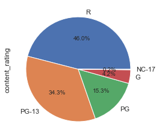

```python
#Drop the 'nan'/missing values  ...this removed 27% of observations
mvdata.dropna(subset=['content_rating'], inplace=True)

#Replace 'Approved','Passed' with Restrcited (R) ...
mvdata.content_rating.replace(['Approved','Passed'], 'R', inplace=True)

#Replace 'Not Rated','Unrated' with General Audience (G) ..
mvdata.content_rating.replace(['Not Rated','Unrated'], 'G', inplace=True)

#Replace 'GP' with Parental Guidance (PG) ..
mvdata.content_rating.replace(['GP'], 'PG', inplace=True)

#Replace 'X','M' with Adults only (NC-17) ..
mvdata.content_rating.replace(['X','M'], 'PG', inplace=True)

mvdata['content_rating'].value_counts().plot(kind='pie',autopct='%.1f%%');
```

**aspect_ratio:**

```
[ 1.78  2.35  1.85  2.    2.2   2.39  2.24  1.66  1.5   1.77  2.4   1.37
   nan  2.76  1.33  1.18  2.55  1.75 16.  ]
```

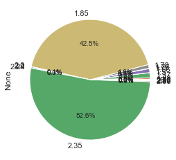

```python
# find out unique values in aspect_ratio ...
print(mvdata['aspect_ratio'].unique())
mvdata.groupby('aspect_ratio').size().plot(kind='pie',autopct='%.1f%%');
```

- Nearly 95% aspect ratios are 1.85 and 2.35. For analyzing purpose, we group other ratios together.
- In order to compute the mean of imdb score for different aspect_ratio, we need to replace NA with 0 first.

```python
#Replace 'nan' with  0...
mvdata['aspect_ratio'].fillna(0, inplace=True)
```

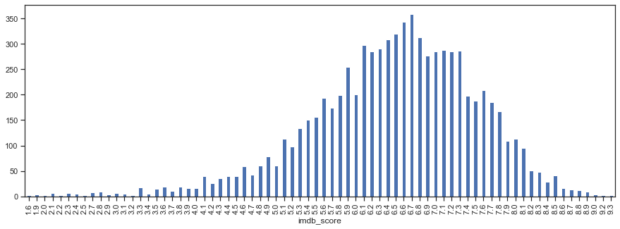

```python
# Individual distribution of aspect_ratio across imdb_score
mvdata.groupby('imdb_score')['aspect_ratio'].sum().plot(kind='bar',figsize=(15,5))
```

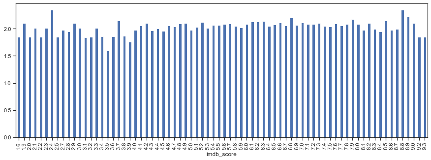

```python
# Individual distribution of aspect_ratio across imdb_score
mvdata.groupby('imdb_score')['aspect_ratio'].mean().plot(kind='bar',figsize=(15,5))
```

```python
#drop 'aspect_ratio' column, because it is near constant and not important feature in predicting imdb_score
mvdata = mvdata.drop('aspect_ratio', axis=1)
```